# Challenge #2

Jyhreh Johnson

4/19/2022

## Challenge 2

```r
library(tidyverse)
```

```r
library(tidyr)
library(mosaic)
library(car)
library(broom)
library(ggplot2)
library(infer)
library(dplyr)
library(skimr)
library(ggpubr)
```

## Preliminaries

• Using the {tidyverse} read_csv() function, load the “AVONETdataset1.csv” dataset from this URL as a “tibble” named d.

```r
f2 <- "https://raw.githubusercontent.com/difiore/ada-2022-datasets/main/AVONETdataset1.csv"
d2 <- read_csv(f2, col_names = TRUE)
head(d2)
```

```
## # A tibble: 6 × 37
##   Sequence Species1     Family1 Order1 Avibase.ID1 Total.individua… Female  Male
##      <dbl> <chr>        <chr>   <chr>  <chr>                  <dbl>  <dbl> <dbl>
## 1     3103 Accipiter a… Accipi… Accip… AVIBASE-BB…                5      2     0
## 2     3090 Accipiter b… Accipi… Accip… AVIBASE-1A…               10      4     6
## 3     3125 Accipiter b… Accipi… Accip… AVIBASE-AD…               11      4     5
## 4     3116 Accipiter b… Accipi… Accip… AVIBASE-68…                4      4     0
## 5     3092 Accipiter b… Accipi… Accip… AVIBASE-84…                8      4     4
## 6     3091 Accipiter b… Accipi… Accip… AVIBASE-6B…                1      0     1
## # … with 29 more variables: Unknown <dbl>, Complete.measures <dbl>,
## #   Beak.Length_Culmen <dbl>, Beak.Length_Nares <dbl>, Beak.Width <dbl>,
## #   Beak.Depth <dbl>, Tarsus.Length <dbl>, Wing.Length <dbl>,
## #   Kipps.Distance <dbl>, Secondary1 <dbl>, `Hand-Wing.Index` <dbl>,
## #   Tail.Length <dbl>, Mass <dbl>, Mass.Source <chr>, Mass.Refs.Other <chr>,
## #   Inference <chr>, Traits.inferred <chr>, Reference.species <chr>,
## #   Habitat <chr>, Habitat.Density <dbl>, Migration <dbl>, …
```

• Winnow the dataset to include only the following variables: Species1, Family1, Order1, Beak.Length_Culmen, Beak.Width, Beak.Depth, Tarsus.Length, Wing.Length, Tail.Length, Mass, Habitat, Migration, Trophic.Level, Trophic.Niche, Min.Latitude, Max.Latitude, Centroid.Latitude, Primary.Lifestyle, ** and Range.Size

```r
d2 <- d2 %>%
  select(Species1,
         Family1,
         Order1,
         Beak.Length_Culmen,
         Beak.Width, Beak.Depth,
         Tarsus.Length,
         Wing.Length,
         Tail.Length,
         Mass,
         Habitat,
         Migration,
         Trophic.Level,
         Trophic.Niche,
         Primary.Lifestyle,
         Min.Latitude,
         Max.Latitude,
         Centroid.Latitude,
         Range.Size)
```

## Step 1

• Create the following two new variables and add them to AVONET dataset: Relative beak length, which you should calculate as the residual of log(Beak.Length_Culmen) on log(Mass).

```r
d2 <- d2 %>% mutate(logBL = log(Beak.Length_Culmen), logMass = log(Mass))
blm <- lm(data = d2, logBL ~ logMass) #linear model
summary(blm) #summarize
```

```
##
## Call:
## lm(formula = logBL ~ logMass, data = d2)
##
## Residuals:
##      Min       1Q   Median       3Q      Max
## -1.21966 -0.21765 -0.04686  0.13787  1.91055
##
## Coefficients:
##             Estimate Std. Error t value Pr(>|t|)
## (Intercept) 1.998025   0.008959   223.0   <2e-16 ***
## logMass     0.277430   0.002138   129.8   <2e-16 ***
## ---
## Signif. codes:  0 '***' 0.001 '**' 0.01 '*' 0.05 '.' 0.1 ' ' 1
##
## Residual standard error: 0.3487 on 11007 degrees of freedom
## Multiple R-squared:  0.6047, Adjusted R-squared:  0.6047
## F-statistic: 1.684e+04 on 1 and 11007 DF,  p-value: < 2.2e-16
```

```r
blm$residuals #get residuals
```

[output not shown]

[output cut: 4349 more lines]

[output not shown]

```r
head(blm$residuals)
```

```
##          1          2          3          4          5          6
## -0.2070788 -0.3256851 -0.3497445 -0.2594067 -0.3992777 -0.3350742
```

• Relative tarsus length, which you should calculate as the residual of log(Tarsus.Length) on log(Mass).

```r
d2 <- d2 %>% mutate(logTL = log(Tarsus.Length), logMass = log(Mass))
tlm <- lm(data = d2, logTL ~ logMass) #linear modl
summary(tlm) #summarize
```

```
##
## Call:
## lm(formula = logTL ~ logMass, data = d2)
##
## Residuals:
##      Min       1Q   Median       3Q      Max
## -1.47702 -0.14835  0.06318  0.22434  1.26132
##
## Coefficients:
##             Estimate Std. Error t value Pr(>|t|)
## (Intercept) 1.976251   0.008687   227.5   <2e-16 ***
## logMass     0.305790   0.002073   147.5   <2e-16 ***
## ---
## Signif. codes:  0 '***' 0.001 '**' 0.01 '*' 0.05 '.' 0.1 ' ' 1
##
## Residual standard error: 0.3381 on 11007 degrees of freedom
## Multiple R-squared:  0.6641, Adjusted R-squared:  0.6641
## F-statistic: 2.176e+04 on 1 and 11007 DF,  p-value: < 2.2e-16
```

```r
tlm$residuals #get residuals
```

[output not shown]

[output cut: 4349 more lines]

[output not shown]

```r
head(tlm$residuals)
```

```
##         1         2         3         4         5         6
## 0.4639465 0.2936955 0.3547687 0.6224533 0.2622459 0.4404059
```

## Step 2

• Make a boxplot or violin plot of your new relative tarsus length variable in relation to Primary.Lifestyle

```r
#create new fields for relative beak length = to its residuals and relative tarsus length = to its residuals
d2 <- d2 %>%
  mutate(rel_beak_len = blm$residuals) %>%
  mutate(rel_tar_len = tlm$residuals)
```

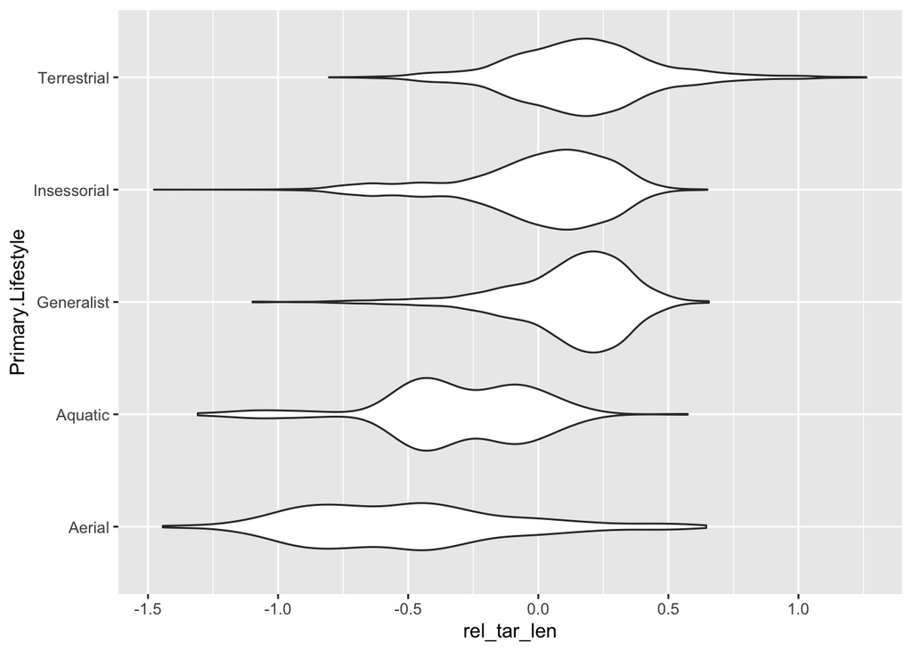

```r
#Create violin plot
t_lifestyle <- ggplot(d2, aes(x = rel_tar_len, y = Primary.Lifestyle)) + geom_violin()
t_lifestyle
```

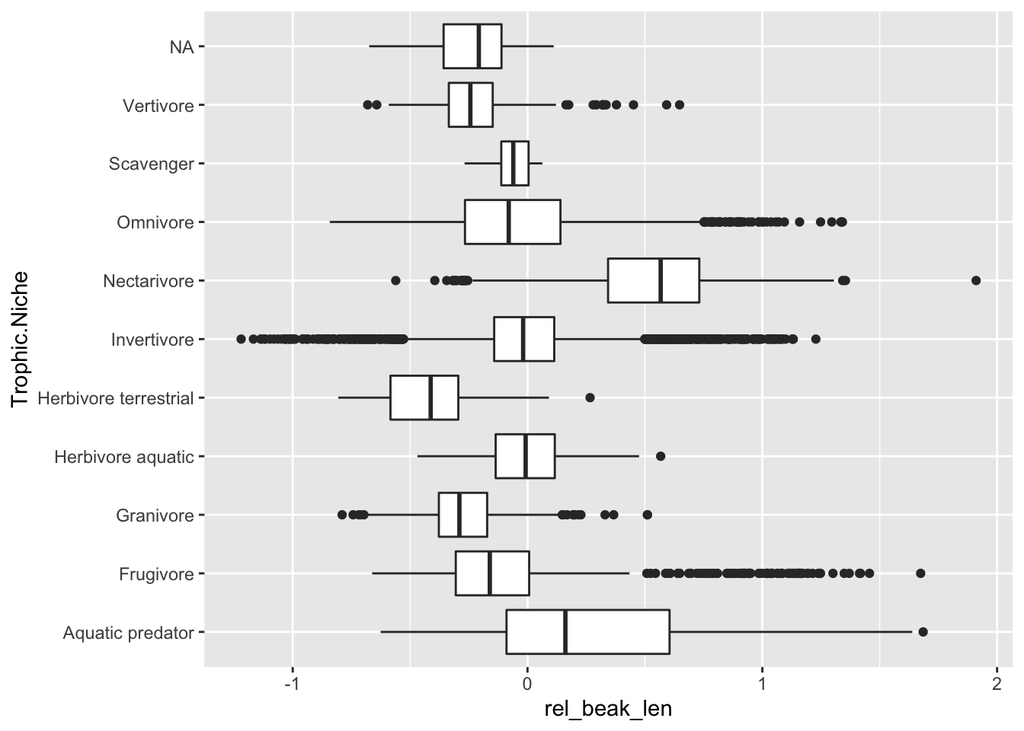

```r
#Create boxplot
bk_lifestyle <- ggplot(d2, aes(x = rel_beak_len, y = Trophic.Niche)) + geom_boxplot()
bk_lifestyle
```

## Step 3

• Run an ANOVA analyses to look at the association between geographic range size and the variable Migration. You should first drop those observations for which Migration is not scored and also look at the distribution of the variable Range.Size to decide whether and how it might need to be transformed. Based on the global model, is range size associated with form of migration? How much of the variance in your measure of range size is associated with Migration behavior style?

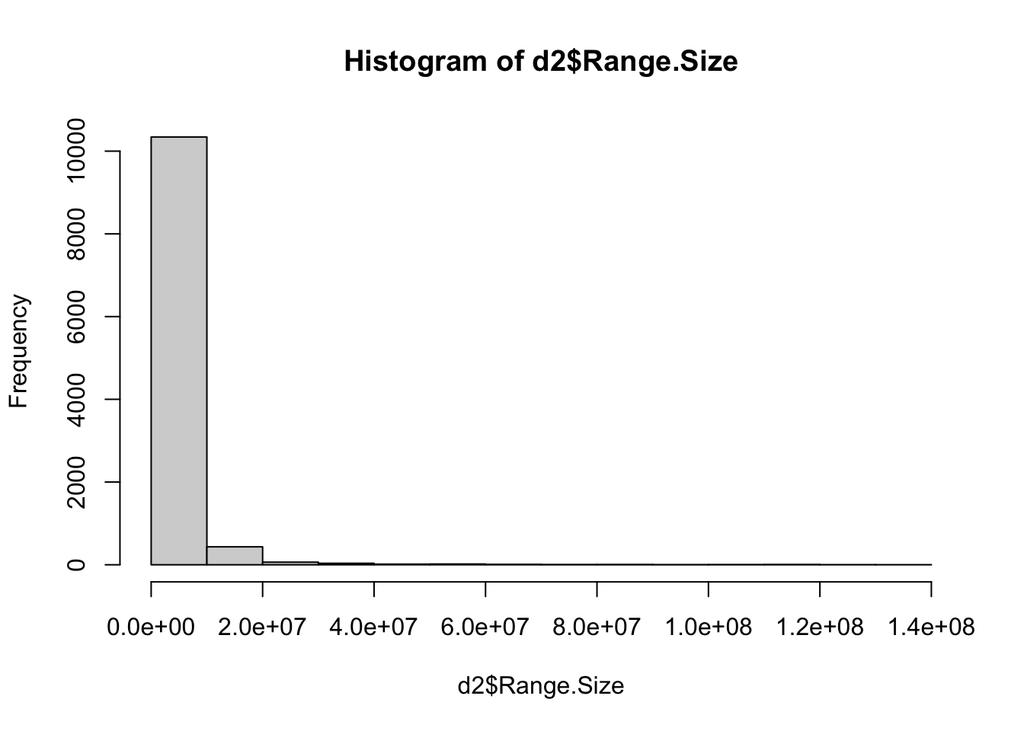

```r
#make a histogram to present range size
hist(d2$Range.Size)
```

```r
d2 <- d2 %>% mutate(logRS = log(Range.Size)) #make new variable in dataset
```

```r
class(d2$Migration) #check Migration classification status
```

```
## [1] "numeric"
```

```r
d2 <- d2 %>% mutate(Migration = as.factor(Migration))
#ANOVA
geo_mig <- aov(data = d2, logRS ~ Migration)
summary(geo_mig)
```

```
##                Df Sum Sq Mean Sq F value Pr(>F)
## Migration       2   8071    4035   520.3 <2e-16 ***
## Residuals   10934  84798       8
## ---
## Signif. codes:  0 '***' 0.001 '**' 0.01 '*' 0.05 '.' 0.1 ' ' 1
## 72 observations deleted due to missingness
```

**Question:** Based on the global model, is range size associated with form of migration?  
**Answer:** Yes

**Question:** How much of the variance in your measure of range size is associated with Migration behavior style?  
**Answer:** I am not sure what you mean by this question? #come back to

• Given the regression coefficients returned in output of the model, which Migration categor(ies) are different than the reference level? What level is the reference level? Relevel and assess differences among the remaining pair of Migration categories.

```r
ref_1 <- d2 %>% mutate(Migration = relevel(Migration, ref = 1))
relevel_r1 <- aov(data = d2, logRS ~ Migration)
summary(relevel_r1)
```

```
##                Df Sum Sq Mean Sq F value Pr(>F)
## Migration       2   8071    4035   520.3 <2e-16 ***
## Residuals   10934  84798       8
## ---
## Signif. codes:  0 '***' 0.001 '**' 0.01 '*' 0.05 '.' 0.1 ' ' 1
## 72 observations deleted due to missingness
```

```r
ref_2 <- d2 %>% mutate(Migration = relevel(Migration, ref = 2))
relevel_r2 <- aov(data = d2, logRS ~ Migration)
summary(relevel_r2)
```

```
##                Df Sum Sq Mean Sq F value Pr(>F)
## Migration       2   8071    4035   520.3 <2e-16 ***
## Residuals   10934  84798       8
## ---
## Signif. codes:  0 '***' 0.001 '**' 0.01 '*' 0.05 '.' 0.1 ' ' 1
## 72 observations deleted due to missingness
```

```r
ref_3 <- d2 %>% mutate(Migration = relevel(Migration, ref = 3))
relevel_r3 <- aov(data = d2, logRS ~ Migration)
summary(relevel_r3)
```

```
##                Df Sum Sq Mean Sq F value Pr(>F)
## Migration       2   8071    4035   520.3 <2e-16 ***
## Residuals   10934  84798       8
## ---
## Signif. codes:  0 '***' 0.001 '**' 0.01 '*' 0.05 '.' 0.1 ' ' 1
## 72 observations deleted due to missingness
```

**Question:** What level is the reference level?  
**Answer:** Aren’t they all the reference level?

• Also conduct a post-hoc Tukey Honest Significant Differences test to also evaluate which Migration categories differ “significantly” from one another (see Module 20).

```r
geo_mig <- aov(data = d2, logRS ~ Migration )
posthoc2 <- TukeyHSD(geo_mig, which = "Migration", ordered = TRUE, conf.level = 0.95)
posthoc2
```

```
##   Tukey multiple comparisons of means
##     95% family-wise confidence level
##     factor levels have been ordered
##
## Fit: aov(formula = logRS ~ Migration, data = d2)
##
## $Migration
##          diff      lwr      upr p adj
## 2-1 1.7846901 1.582952 1.986428     0
## 3-1 2.5170168 2.297150 2.736883     0
## 3-2 0.7323266 0.450689 1.013964     0
```

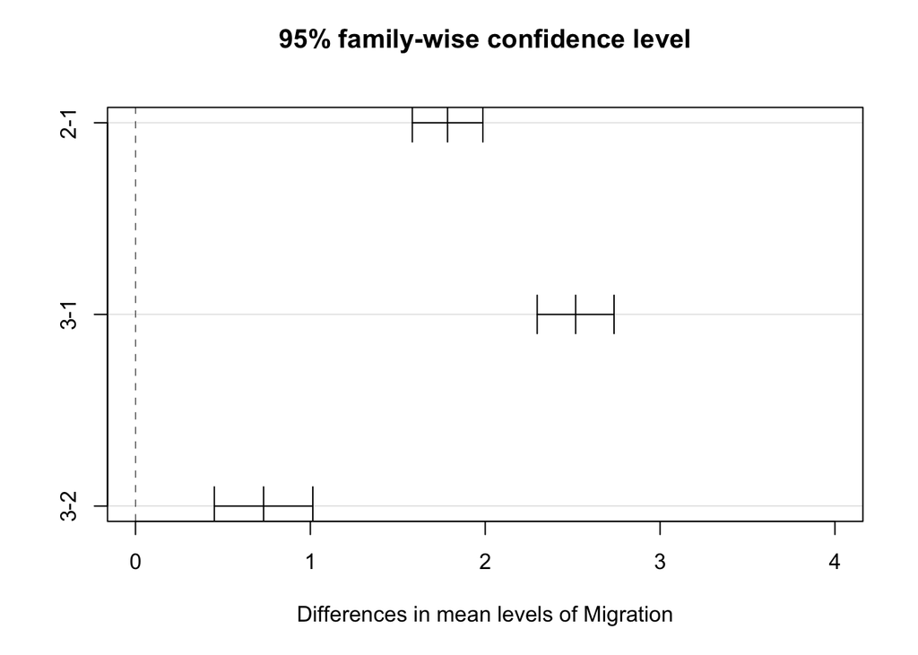

```r
plot(posthoc2, xlim = c(0, 4))
```

• Winnow your original data to just consider birds from the Infraorder “Passeriformes” (song birds).

```r
passer <- d2 %>% filter(Order1 == "Passeriformes")
```

• Run separate one-factor ANOVA analyses to look at the association between [1] relative beak length and Primary.Lifestyle and between [2] relative beak length and Trophic.Level. In doing so…

**ANOVA analysis**

```r
#relative beak length to Primary.Lifestyle
beak_len_pl <- aov(data = passer, rel_beak_len ~ Primary.Lifestyle)
summary(beak_len_pl)
```

```
##                     Df Sum Sq Mean Sq F value Pr(>F)
## Primary.Lifestyle    3   18.2   6.067   130.2 <2e-16 ***
## Residuals         6610  307.9   0.047
## ---
## Signif. codes:  0 '***' 0.001 '**' 0.01 '*' 0.05 '.' 0.1 ' ' 1
```

```r
#relative beak length to Trophic.Level
beak_len_tl <- aov(data = passer, rel_beak_len ~ Trophic.Level)
summary(beak_len_tl)
```

```
##                 Df Sum Sq Mean Sq F value Pr(>F)
## Trophic.Level    2  16.31   8.154     174 <2e-16 ***
## Residuals     6611 309.81   0.047
## ---
## Signif. codes:  0 '***' 0.001 '**' 0.01 '*' 0.05 '.' 0.1 ' ' 1
```

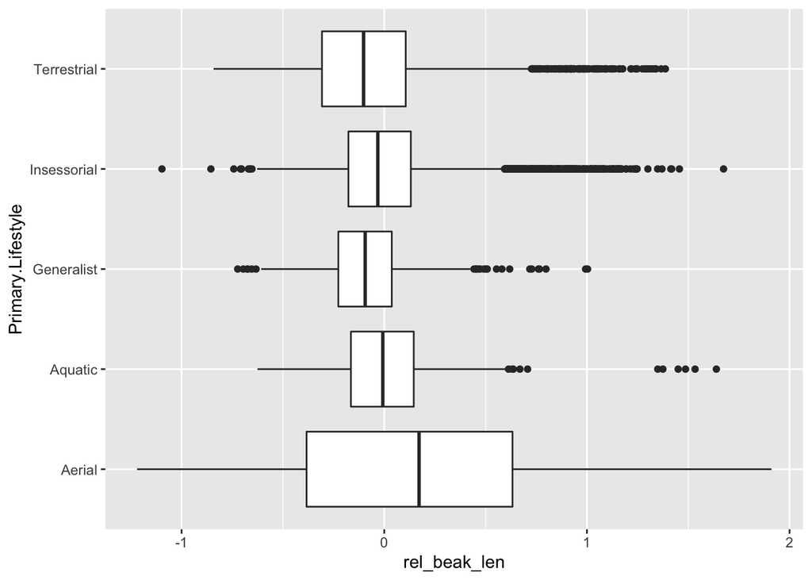

```r
#Boxplot of Primary.Lifestyle
beak_prime <- ggplot(d2, aes(x = rel_beak_len, y = Primary.Lifestyle )) + geom_boxplot()
beak_prime
```

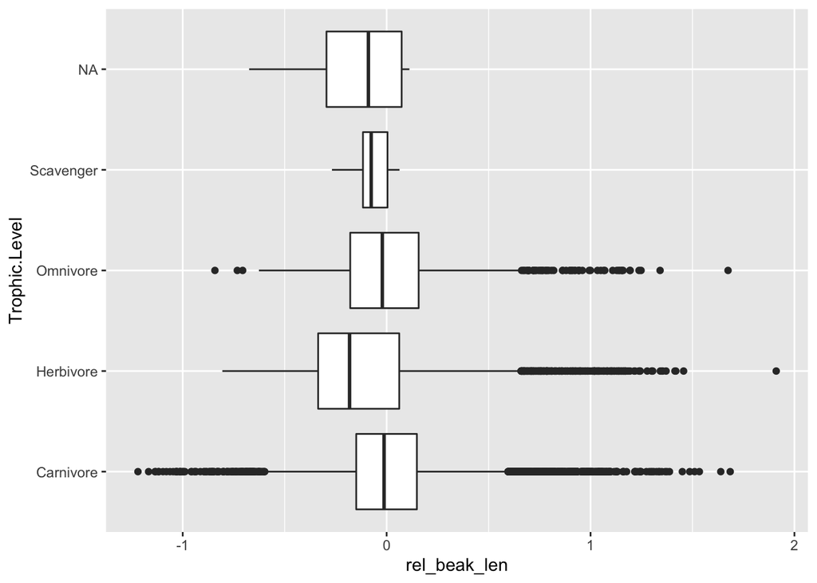

```r
#Boxplot of Trophic.Level
beak_troph <- ggplot(d2, aes(x = rel_beak_len, y = Trophic.Level)) + geom_boxplot()
beak_troph
```

• Run linear models for each predictor separately and interpret the model output.

```r
#linear model for relative beak length with passer PL & TL
beak_len_pl_pass <- lm(data = passer, rel_beak_len ~ Primary.Lifestyle)
summary(beak_len_pl_pass)
```

```
##
## Call:
## lm(formula = rel_beak_len ~ Primary.Lifestyle, data = passer)
##
## Residuals:
##     Min      1Q  Median      3Q     Max
## -0.6314 -0.1380 -0.0172  0.1118  1.2241
##
## Coefficients:
##                              Estimate Std. Error t value Pr(>|t|)
## (Intercept)                  -0.34950    0.02158  -16.19   <2e-16 ***
## Primary.LifestyleGeneralist   0.27926    0.02306   12.11   <2e-16 ***
## Primary.LifestyleInsessorial  0.35342    0.02181   16.20   <2e-16 ***
## Primary.LifestyleTerrestrial  0.27924    0.02249   12.42   <2e-16 ***
## ---
## Signif. codes:  0 '***' 0.001 '**' 0.01 '*' 0.05 '.' 0.1 ' ' 1
##
## Residual standard error: 0.2158 on 6610 degrees of freedom
## Multiple R-squared:  0.05581,    Adjusted R-squared:  0.05538
## F-statistic: 130.2 on 3 and 6610 DF,  p-value: < 2.2e-16
```

```r
beak_len_tl_pass <- lm(data = passer, rel_beak_len ~ Trophic.Level)
summary(beak_len_tl_pass)
```

```
##
## Call:
## lm(formula = rel_beak_len ~ Trophic.Level, data = passer)
##
## Residuals:
##      Min       1Q   Median       3Q      Max
## -0.67045 -0.13692 -0.02063  0.11129  1.23116
##
## Coefficients:
##                         Estimate Std. Error t value Pr(>|t|)
## (Intercept)            -0.003170   0.003501  -0.906  0.36518
## Trophic.LevelHerbivore -0.118713   0.006956 -17.066  < 2e-16 ***
## Trophic.LevelOmnivore   0.017902   0.006606   2.710  0.00675 **
## ---
## Signif. codes:  0 '***' 0.001 '**' 0.01 '*' 0.05 '.' 0.1 ' ' 1
##
## Residual standard error: 0.2165 on 6611 degrees of freedom
## Multiple R-squared:  0.05001,    Adjusted R-squared:  0.04972
## F-statistic:   174 on 2 and 6611 DF,  p-value: < 2.2e-16
```

• Run a two-factor model to look at the association between relative beak length and both Primary.Lifestyle and Trophic.Level among the passariforms.

```r
#run the two-factor model with ANOVA
tfm <- aov(data = passer, rel_beak_len ~ Primary.Lifestyle + Trophic.Level)
summary(tfm)
```

```
##                     Df Sum Sq Mean Sq F value Pr(>F)
## Primary.Lifestyle    3  18.20   6.067   138.1 <2e-16 ***
## Trophic.Level        2  17.68   8.838   201.2 <2e-16 ***
## Residuals         6608 290.24   0.044
## ---
## Signif. codes:  0 '***' 0.001 '**' 0.01 '*' 0.05 '.' 0.1 ' ' 1
```

**Question:** Based on the model output, what would you conclude about how relative beak length is related to these two variables?  
**Answer:** They all appear to be significantly associated with each other.

• Finally, run an additional two-way model with the same dataset and predictors, but adding the possibility of an interaction term. To do this, you should modify your model formula using the colon operator (:) to specify the interaction, e.g., relative beak length ~ Primary.Lifestyle + Trophic.Level + Primary.Lifestyle:Trophic.Level.

```r
#Use the colon operator(:) at the end of the two-factor ANOVA
tfm2 <- aov(data = passer, rel_beak_len ~ Primary.Lifestyle + Trophic.Level + Primary.Lifestyle:Trophic.Level)
summary(tfm2)
```

```
##                                   Df Sum Sq Mean Sq F value Pr(>F)
## Primary.Lifestyle                  3  18.20   6.067  142.15 <2e-16 ***
## Trophic.Level                      2  17.68   8.838  207.11 <2e-16 ***
## Primary.Lifestyle:Trophic.Level    4   8.41   2.102   49.26 <2e-16 ***
## Residuals                       6604 281.83   0.043
## ---
## Signif. codes:  0 '***' 0.001 '**' 0.01 '*' 0.05 '.' 0.1 ' ' 1
```

**Question:** Based on the model output, what would you now conclude about how relative beak length is related to these two variables?  
**Answer:** Even as they intersect, the relative beak lengths are still significantly associated.

• Use the interaction.plot() function to visualize the interaction between Primary.Lifestyle and Trophic.Level (see Module 20).

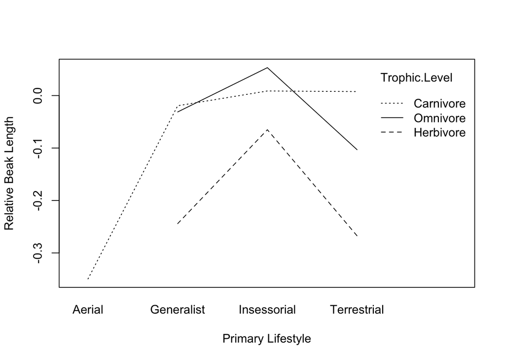

```r
#interaction plot of PL and TL
interaction.plot(
  x.factor = passer$Primary.Lifestyle,
  xlab = "Primary Lifestyle",
  trace.factor = passer$Trophic.Level,
  trace.label = "Trophic.Level",
  response = passer$rel_beak_len,
  fun = base::mean,
  ylab = "Relative Beak Length"
)
```

## Additional Steps?

In the exercise above, we really did not do any checking with this dataset to see if the data meet the primary assumptions for standard linear regression and ANOVA, which are that variables/residuals within each grouping level are roughly normally distributed and have roughly equal variances. Sample sizes within each grouping level should also be roughly equal. As noted in Module 20, a general rule of thumb for “equal” variances is to compare the largest and smallest within-grouping level standard deviations and, if this value is less than 2, then it is often reasonable to presume the assumption may not be violated.

Use this approach to see whether variances in across groups in your various models (e.g., for relative beak length ~ trophic level) are roughly equal. Additionally, do a visual check of whether observations and model residuals within groups look to be normally distributed.

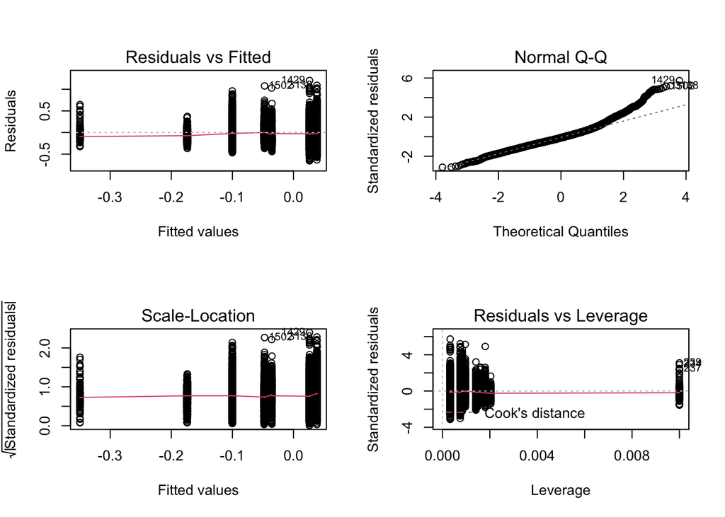

```r
#not sure if this is what you meant? I don't think this is right lol.
par(mfrow = c(2, 2))
plot(tfm)
```

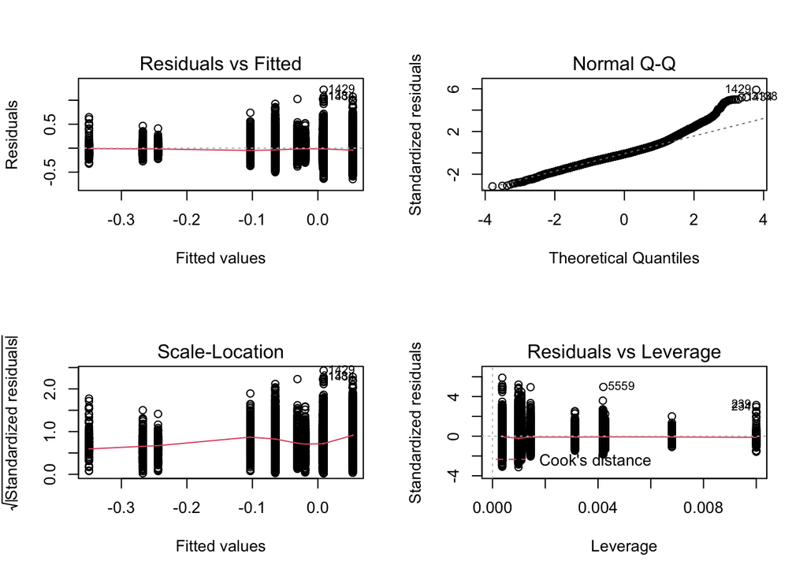

```r
plot(tfm2)
```